# iDEP: Investigating Differentially Expressed Genes

## If this site has contributed to your work, please cite our article:

Ge, S.X., Son, E.W. & Yao, R. iDEP: an integrated web application for differential expression and pathway analysis of RNA-Seq data. BMC Bioinformatics 19, 534 (2018). https://doi.org/10.1186/s12859-018-2486-6

## Summary

Read Counts data were analyzed using iDEP v2.4.3. The data was first filtered to remove reads below 0.5 CPM in at least 1 sample. Then the data was transformed with EdgeR using a pseudocount of 4. Missing values were imputed using geneMedian.

After mapping, there are 42278 unique genes in 39 samples. Of the 31252 genes passed filter, 31189 were converted to Ensembl/STRING gene IDs in our database. The remaining 63 genes were kept in the data using original IDs.

Differential expression analysis was performed using DESeq2 with an FDR cutoff of 0.1 and a minimum fold-change threshold of 2. Standard Wald test was used and independent filtering was disabled.

## Selected Comparison: ANTHO_LESS_&*0_CGY-WT*&_0_CGY

Up-regulated genes: 11

Down-regulated genes: 13

## Top Up-regulated Genes

```r
if (!is.null(params$up_genes_table) && nrow(params$up_genes_table) > 0) {
  kbl(params$up_genes_table, escape = FALSE) %>%
    kable_classic(full_width = FALSE, html_font = "Cambria")
} else {
  print("No up-regulated genes found for this comparison.")
}
```

| Symbol | Ensembl ID | log2 FC | Adj. P-value | Description |
| --- | --- | --- | --- | --- |
| BRA033627 | BRA033627 | 5.169 | 7.94e-02 | AT4G39530 (E=0.0) \| pentatricopeptide (PPR) repeat-containing protein |
| BRA027045 | BRA027045 | 4.948 | 4.13e-02 | AT5G49980 (E=6e-008) AFB5 \| AFB5 (Auxin F-Box protein 5) |
| BRA016183 | BRA016183 | 4.325 | 5.09e-03 | AT2G07760 (E=3e-015) \| zinc knuckle (CCHC-type) family protein |
| BRA021939 | BRA021939 | 3.822 | 7.83e-02 | AT2G34920 (E=1e-097) EDA18 \| EDA18 (embryo sac development arrest 18) |
| BRA008872 | BRA008872 | 3.071 | 4.78e-02 | AT5G12900 (E=1e-187) \| unknown protein |
| BRA008190 | BRA008190 | 3.028 | 4.78e-02 | AT1G75360 (E=5e-037) \| unknown protein |
| BRA014977 | BRA014977 | 2.357 | 4.13e-02 | AT3G23750 (E=3e-223) \| leucine-rich repeat family protein / protein kinase family protein |
| BRA036316 | BRA036316 | 2.095 | 5.91e-02 | AT4G01700 (E=3e-135) \| chitinase, putative |
| BRA025331 | BRA025331 | 1.858 | 4.13e-02 | AT3G28390 (E=0.0) PGP18 \| PGP18 (P-GLYCOPROTEIN 18) |
| BRA040211 | BRA040211 | 1.750 | 9.83e-02 | AT3G04140 (E=5e-285) \| ankyrin repeat family protein |
| BRA034887 | BRA034887 | 1.670 | 3.91e-02 | AT5G40450 (E=2e-016) \| unknown protein |

## Top Down-regulated Genes

```r
if (!is.null(params$down_genes_table) && nrow(params$down_genes_table) > 0) {
  kbl(params$down_genes_table, escape = FALSE) %>%
    kable_classic(full_width = FALSE, html_font = "Cambria")
} else {
  print("No down-regulated genes found for this comparison.")
}
```

| Symbol | Ensembl ID | log2 FC | Adj. P-value | Description |
| --- | --- | --- | --- | --- |
| BRA015556 | BRA015556 | -6.812 | 3.91e-02 | AT1G07150 (E=1e-051) MAPKKK13 \| MAPKKK13 |
| BRA016440 | BRA016440 | -6.052 | 4.13e-02 |  |
| BRA014918 | BRA014918 | -5.955 | 5.60e-02 |  |
| BRA029497 | BRA029497 | -5.691 | 1.93e-02 |  |
| BRA012114 | BRA012114 | -4.937 | 6.78e-02 | AT5G66900 (E=3e-217) \| disease resistance protein (CC-NBS-LRR class), putative |
| BRA015748 | BRA015748 | -4.470 | 4.78e-02 | AT1G76430 (E=9e-224) \| phosphate transporter family protein |
| BRA028219 | BRA028219 | -4.172 | 1.29e-03 | AT5G39000 (E=0.0) \| protein kinase family protein |
| BRA002503 | BRA002503 | -3.888 | 5.60e-02 | AT5G60210 (E=4e-192) \| LOCATED IN: plasma membrane |
| BRA036936 | BRA036936 | -3.712 | 4.78e-02 | AT1G43910 (E=2e-221) \| AAA-type ATPase family protein |
| BRA009519 | BRA009519 | -2.980 | 3.91e-02 | AT5G03670 (E=2e-190) \| unknown protein |
| BRA003802 | BRA003802 | -2.822 | 3.91e-02 | AT1G74420 (E=5e-107) FUT3, ATFUT3 \| FUT3 (FUCOSYLTRANSFERASE 3) |
| BRA019837 | BRA019837 | -2.754 | 3.91e-02 | AT1G11700 (E=1e-077) \| unknown protein |
| BRA020508 | BRA020508 | -2.442 | 5.60e-02 | AT5G25610 (E=5e-169) RD22 \| RD22 |

## DEG Heatmap

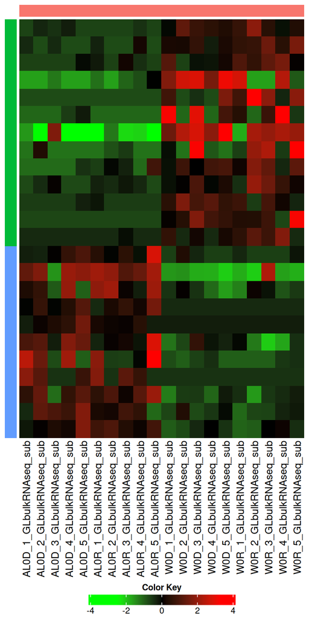

```r
if (!is.null(params$heat_data) && !is.null(params$heat_bar)) {
  heat_colors <- unlist(strsplit(params$heatmap_color_select, "-"))

  deg_heatmap(
    df = params$heat_data,
    bar = params$heat_bar,
    heatmap_color_select = heat_colors,
    cluster_rows = FALSE
  )
}
```

## Volcano Plot

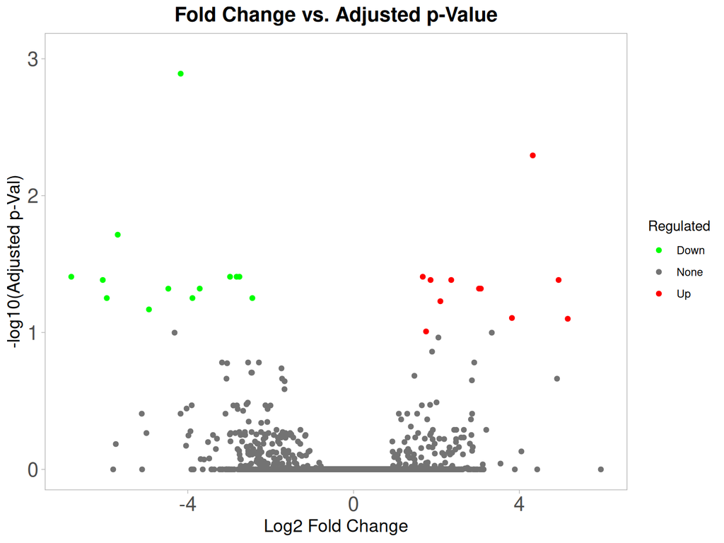

```r
if (!is.null(params$vol_data) && !is.null(params$vol_data$data)) {
  p <- plot_volcano(
    data = params$vol_data$data,
    plot_colors = params$plot_colors,
    anotate_genes = params$gene_labels_volcano
  )
  p <- refine_ggplot2(
    p = p,
    gridline = params$plot_grid_lines,
    ggplot2_theme = params$ggplot2_theme
  )
  print(p)
}
```

## MA Plot

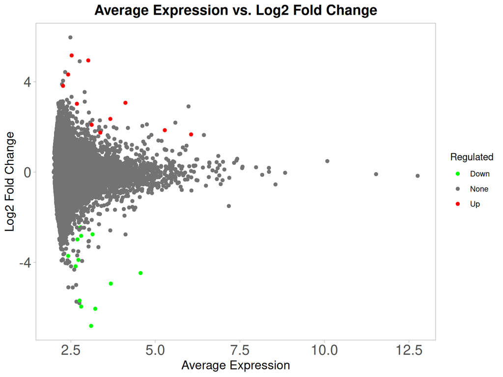

```r
if (!is.null(params$vol_data) && !is.null(params$vol_data$data)) {
  p <- plot_ma(
    data = params$vol_data$data,
    plot_colors = params$plot_colors,
    anotate_genes = params$gene_labels_ma
  )
  p <- refine_ggplot2(
    p = p,
    gridline = params$plot_grid_lines,
    ggplot2_theme = params$ggplot2_theme
  )
  print(p)
}
```

## Scatter Plot

[figure not shown]

```r
if (!is.null(params$top_genes) && !is.null(params$comparisons)) {
  p <- plot_deg_scatter(
    select_contrast = params$select_contrast,
    comparisons = params$comparisons,
    top_genes = params$top_genes,
    limma_p_val = params$limma_p_val,
    limma_fc = params$limma_fc,
    contrast_samples = params$contrast_samples,
    processed_data = params$processed_data,
    sample_info = params$sample_info,
    plot_colors = params$plot_colors,
    all_gene_names = params$all_gene_names,
    select_gene_id = params$select_gene_id,
    anotate_genes = params$gene_labels_scatter
  )
  p <- refine_ggplot2(
    p = p,
    gridline = params$plot_grid_lines,
    ggplot2_theme = params$ggplot2_theme
  )
  print(p)
}
```

Generated using iDEP v2.4.3 (https://bioinformatics.sdstate.edu/idep). 2025-12-10 20:51:10 UTC. Accuracy not guaranteed.